# Machine learning - Assingment 4

Felipe Wolff

2023-05-19

# Executive summary

This article is the final report for Practical Machine Learning course, as part of the Data Science Specialization track offered by John Hopkins, in Coursera website. This project use data from accelerometers on the belt, forearm, arm, and dumbell of 6 participants to predict the manner in which they did the exercise. This is the “classe” variable in the training set. We train 4 models: Decision Tree, Random Forest, Gradient Boosted Trees, Support Vector Machine using k-folds cross validation on the training set. We then predict using a validation set randomly selected from the training csv data to obtain the accuracy and out of sample error rate. In this project, we will use data from accelerometers on the belt, forearm, arm, and dumbell of 6 participants to predict the manner in which they did the exercise.

# Library

```r
library(lattice)
library(ggplot2)
library(caret)
library(kernlab)
library(rattle)
library(corrplot)
set.seed(1234)
```

# Getting and cleaning data

## Download the Data

```r
trainUrl <-"https://d396qusza40orc.cloudfront.net/predmachlearn/pml-training.csv"
testUrl <- "https://d396qusza40orc.cloudfront.net/predmachlearn/pml-testing.csv"
trainFile <- "./data/pml-training.csv"
testFile  <- "./data/pml-testing.csv"
if (!file.exists("./data")) {
  dir.create("./data")
}
if (!file.exists(trainFile)) {
  download.file(trainUrl, destfile=trainFile, method="curl")
}
if (!file.exists(testFile)) {
  download.file(testUrl, destfile=testFile, method="curl")
}
```

## Read and cleaning the Data

After downloading the data from the data source, we can read the two csv files into two data frames.

```r
train_set <- read.csv("./data/pml-training.csv")
test_set <- read.csv("./data/pml-testing.csv")
dim(train_set)
```

```
## [1] 19622   160
```

```r
dim(test_set)
```

```
## [1]  20 160
```

Removing NA variables and other unnecessary metadata

```r
train_set <- train_set[,colMeans(is.na(train_set))< .9]
train_set <- train_set[, -c(1:7)]
dim(train_set)
```

```
## [1] 19622    86
```

Removing Near Zero Variance:

```r
zv <- nearZeroVar(train_set)
train_set <- train_set[,-zv]
dim(train_set)
```

```
## [1] 19622    53
```

Now, we can split the data in Validation and training sets.

```r
training <- createDataPartition(y=train_set$classe, p=0.7, list=F)
train <- train_set[training,]
validation <- train_set[-training,]
```

# Creation and test the models

Here we will use these models to test: SVM, Decision trees, Random forest and Gradient boosted trees. These with the purpose of comparison among them. We will set up the control with 3-fold cross validation.

```r
ctrl <- trainControl(method="cv", number=3, verboseIter=F)
```

## Support Vector Machine

```r
mod_svm <- train(classe~., data = train, method="svmLinear",
                 trControl= ctrl, tuneLength = 5, verbose=F)
pred_svm <- predict(mod_svm, validation)
conf_matrix <- confusionMatrix(pred_svm, factor(validation$classe))
conf_matrix
```

```
## Confusion Matrix and Statistics
##
##           Reference
## Prediction    A    B    C    D    E
##          A 1537  154   79   69   50
##          B   29  806   90   46  152
##          C   40   81  797  114   69
##          D   61   22   32  697   50
##          E    7   76   28   38  761
##
## Overall Statistics
##
##                Accuracy : 0.7813
##                  95% CI : (0.7705, 0.7918)
##     No Information Rate : 0.2845
##     P-Value [Acc > NIR] : < 2.2e-16
##
##                   Kappa : 0.722
##
##  Mcnemar's Test P-Value : < 2.2e-16
##
## Statistics by Class:
##
##                      Class: A Class: B Class: C Class: D Class: E
## Sensitivity            0.9182   0.7076   0.7768   0.7230   0.7033
## Specificity            0.9164   0.9332   0.9374   0.9665   0.9690
## Pos Pred Value         0.8137   0.7177   0.7239   0.8086   0.8363
## Neg Pred Value         0.9657   0.9301   0.9521   0.9468   0.9355
## Prevalence             0.2845   0.1935   0.1743   0.1638   0.1839
## Detection Rate         0.2612   0.1370   0.1354   0.1184   0.1293
## Detection Prevalence   0.3210   0.1908   0.1871   0.1465   0.1546
## Balanced Accuracy      0.9173   0.8204   0.8571   0.8447   0.8362
```

## Decision Tree

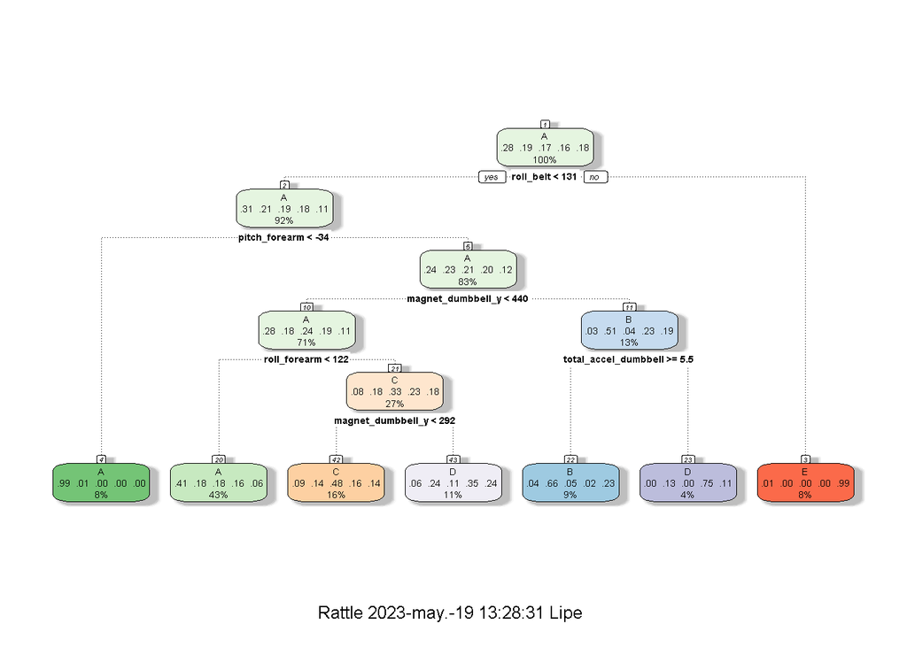

```r
mod_dtrees <- train(classe~., data=train, method="rpart",
                    trControl= ctrl, tuneLength = 5)
fancyRpartPlot(mod_dtrees$finalModel)
```

*Predictions*

```r
pred_dtrees <- predict(mod_dtrees, validation)
conf_mdtrees <- confusionMatrix(pred_dtrees, factor(validation$classe))
conf_mdtrees
```

```
## Confusion Matrix and Statistics
##
##           Reference
## Prediction    A    B    C    D    E
##          A 1519  473  484  451  156
##          B   28  355   45   10  130
##          C   83  117  423  131  131
##          D   40  194   74  372  176
##          E    4    0    0    0  489
##
## Overall Statistics
##
##                Accuracy : 0.5366
##                  95% CI : (0.5238, 0.5494)
##     No Information Rate : 0.2845
##     P-Value [Acc > NIR] : < 2.2e-16
##
##                   Kappa : 0.3957
##
##  Mcnemar's Test P-Value : < 2.2e-16
##
## Statistics by Class:
##
##                      Class: A Class: B Class: C Class: D Class: E
## Sensitivity            0.9074  0.31168  0.41228  0.38589  0.45194
## Specificity            0.6286  0.95512  0.90492  0.90165  0.99917
## Pos Pred Value         0.4927  0.62500  0.47797  0.43458  0.99189
## Neg Pred Value         0.9447  0.85255  0.87940  0.88228  0.89002
## Prevalence             0.2845  0.19354  0.17434  0.16381  0.18386
## Detection Rate         0.2581  0.06032  0.07188  0.06321  0.08309
## Detection Prevalence   0.5239  0.09652  0.15038  0.14545  0.08377
## Balanced Accuracy      0.7680  0.63340  0.65860  0.64377  0.72555
```

## Random Forest

```r
model_rf <- train(classe~.,data=train, method="rf", trControl=ctrl,
                  tuneLength = 5)
pred_rf <- predict(model_rf, validation)
conf_mrf <- confusionMatrix(pred_rf, factor(validation$classe))
conf_mrf
```

```
## Confusion Matrix and Statistics
##
##           Reference
## Prediction    A    B    C    D    E
##          A 1673    3    0    0    0
##          B    1 1132   11    0    0
##          C    0    4 1013    6    0
##          D    0    0    2  957    0
##          E    0    0    0    1 1082
##
## Overall Statistics
##
##                Accuracy : 0.9952
##                  95% CI : (0.9931, 0.9968)
##     No Information Rate : 0.2845
##     P-Value [Acc > NIR] : < 2.2e-16
##
##                   Kappa : 0.994
##
##  Mcnemar's Test P-Value : NA
##
## Statistics by Class:
##
##                      Class: A Class: B Class: C Class: D Class: E
## Sensitivity            0.9994   0.9939   0.9873   0.9927   1.0000
## Specificity            0.9993   0.9975   0.9979   0.9996   0.9998
## Pos Pred Value         0.9982   0.9895   0.9902   0.9979   0.9991
## Neg Pred Value         0.9998   0.9985   0.9973   0.9986   1.0000
## Prevalence             0.2845   0.1935   0.1743   0.1638   0.1839
## Detection Rate         0.2843   0.1924   0.1721   0.1626   0.1839
## Detection Prevalence   0.2848   0.1944   0.1738   0.1630   0.1840
## Balanced Accuracy      0.9993   0.9957   0.9926   0.9962   0.9999
```

## Gradient Boosted Trees

```r
model_gbt <- train(classe~., data= train, method="gbm",trControl=ctrl,
                  tuneLength=5, verbose=F)
pred_gbt <- predict(model_gbt, validation)
conf_mgbt <- confusionMatrix(pred_gbt, factor(validation$classe))
conf_mgbt
```

```
## Confusion Matrix and Statistics
##
##           Reference
## Prediction    A    B    C    D    E
##          A 1670    5    0    0    0
##          B    1 1127   12    1    0
##          C    3    7 1011    9    4
##          D    0    0    3  950    1
##          E    0    0    0    4 1077
##
## Overall Statistics
##
##                Accuracy : 0.9915
##                  95% CI : (0.9888, 0.9937)
##     No Information Rate : 0.2845
##     P-Value [Acc > NIR] : < 2.2e-16
##
##                   Kappa : 0.9893
##
##  Mcnemar's Test P-Value : NA
##
## Statistics by Class:
##
##                      Class: A Class: B Class: C Class: D Class: E
## Sensitivity            0.9976   0.9895   0.9854   0.9855   0.9954
## Specificity            0.9988   0.9971   0.9953   0.9992   0.9992
## Pos Pred Value         0.9970   0.9877   0.9778   0.9958   0.9963
## Neg Pred Value         0.9990   0.9975   0.9969   0.9972   0.9990
## Prevalence             0.2845   0.1935   0.1743   0.1638   0.1839
## Detection Rate         0.2838   0.1915   0.1718   0.1614   0.1830
## Detection Prevalence   0.2846   0.1939   0.1757   0.1621   0.1837
## Balanced Accuracy      0.9982   0.9933   0.9903   0.9923   0.9973
```

# Results

[output not shown]

```r
pred_rf <- predict(model_rf, test_set)
pred_rf
```

```
##  [1] B A B A A E D B A A B C B A E E A B B B
## Levels: A B C D E
```

# Appendix

correlation matrix in training set

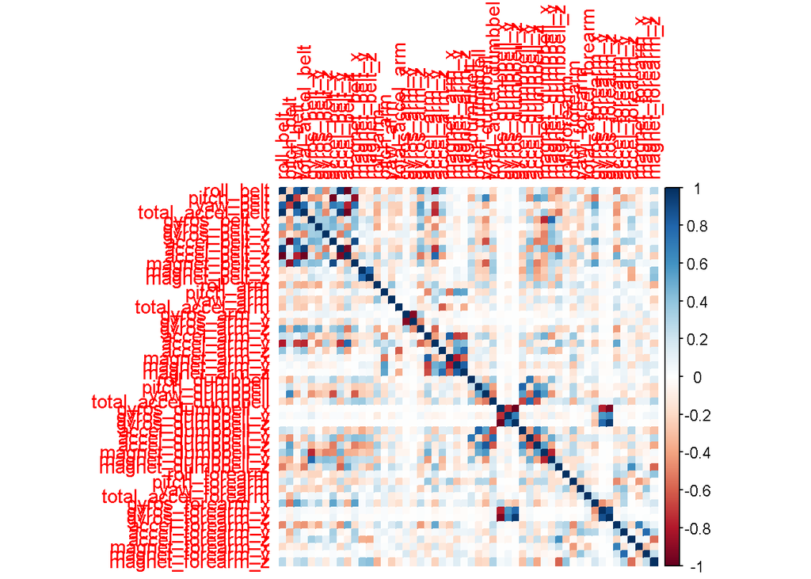

```r
corr_plot <- cor(train[,-length(names(train))])
corrplot(corr_plot, method = "color")
```